Universidad del Pacífico

AI and Economic Modeling · Track B: the model behind my thesis

[figure not shown]

# Economic freedom and firm entry–exit decisions

Gabriel Saco

Professor: Alexander Quispe

github.com/gsaco/ai-project

Lima · October 2026

## Why might losses exceed gains?

01 · Question and thesis evidence

Symmetry imposedAsymmetry allowed

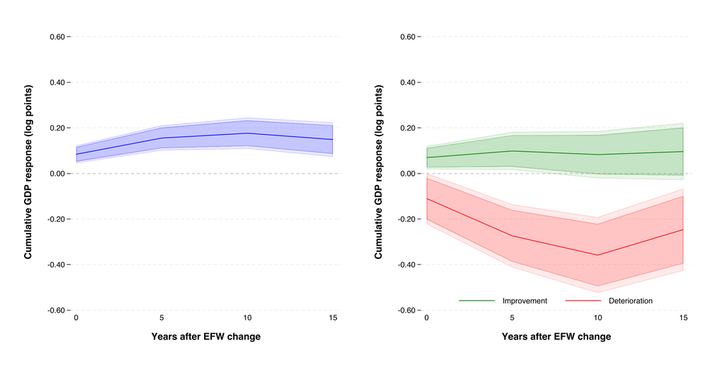

## From economic freedom to two firm-level channels

02 · Institutional channels

Economic freedom concerns the ability to use property, make contracts, and exchange. The Economic Freedom of the World (EFW) index measures several institutional dimensions.

Five areas of the EFW index [Fraser Institute ↗](https://efotw.org/economic-freedom/approach)

| Area 1 | Area 2 | Area 3 | Area 4 | Area 5 |
| --- | --- | --- | --- | --- |
| Size of government | Legal system and property rights | Sound money | Freedom to trade internationally | Regulation |

s **Institutionally usable property**

Share of existing property available for productive use under prevailing institutional conditions. Title disputes or restrictions on property use can make premises unavailable.

Less usable property: $s\downarrow$

c **Institution-related operating overhead**

Recurring institutional expenses paid while operating, independently of current output. Examples include permit renewals and fixed costs of reporting or customs administration.

Higher operating overhead: $c\uparrow$

## From usable property to production

02 · Operating profit

### Fixed property

$$\bar k>0$$

The firm’s existing stock.

$\times$

### Usable share

$$s\in(0,1]$$

Determined by institutions.

$=$

### Usable property

$$s\bar k$$

Available for production.

### 1 · Combine property with input

Assume Cobb–Douglas production:

$$q=A(s\bar k)^{1-\alpha}x^\alpha.$$

$x\geq0$: variable input.  
$A>0$: productivity.  
$0<\alpha<1$: output elasticity of $x$.

Output sells for one, so output equals revenue.

### 2 · Choose convenient units

Measure property in units of the firm’s fixed stock: $\bar k=1$.

$$\boxed{q=As^{1-\alpha}x^\alpha.}$$

Example: s = 0.5Fixed stock = 1

UsableUnavailable

Half the existing stock is available for production.

An institutional shock changes the usable share $s$. The physical stock $\bar k$ stays fixed.

## One experiment, one changed assumption

02 · Baseline and model assumptions

### Baseline: free restarting

$$\kappa=0$$

### Extension: costly restarting

$$\kappa>0$$

| Institutional path | Shock: $t=0$ | Restored: $t\geq1$ |
| --- | --- | --- |
| Deterioration | $s_0-d$ | $s_0$ |
| No change | $s_0$ | $s_0$ |
| Improvement | $s_0+d$ | $s_0$ |

### Same firm and known restoration

Initially open; $0<d<s_0$, $s_0+d\leq1$. Restoration is permanent and known at date 0. Hold $c=c_0$ and other parameters fixed.

### What closure means

Free closure preserves property but dismantles the organization. No organization-preserving suspension; financing is available. Profits are discounted by $0<\beta<1$.

## The complete firm problem

02 · Choices and objective

### Activity · $a_t\in\{0,1\}$

$1$: open. $0$: closed. Initially, $a_{-1}=1$.

### Variable input · $x_t\geq0$

Choose input when open; set $x_t=0$ when closed.

### Choose activity and input over time to maximize firm value

$$\max_{\{a_t,x_t\}}\sum_{t=0}^{\infty}\beta^t\left[
As_t^{1-\alpha}x_t^\alpha-wx_t-(F+c_t)a_t-\kappa a_t(1-a_{t-1})\right].$$

### Revenue

$$As_t^{1-\alpha}x_t^\alpha$$

$A>0$ is productivity. Output price is one, so output equals revenue.

### Input bill

$$wx_t$$

Input quantity $x_t$ times its fixed unit price $w>0$.

### Operating overhead

$$(F+c_t)a_t$$

$F>0$: ordinary fixed cost.  
$c_t\geq0$: institutional overhead.  
Both are paid only when open.

### Restart cost

$$\kappa a_t(1-a_{t-1})$$

Pay $\kappa\geq0$ only when closed last period and open now. Otherwise, pay zero.

## Restart costs leave the input FOC unchanged

03 · The expected first-order condition

### 1 · Hold the operating decision fixed

Choose the variable input $x$ to maximize operating profit:

$$\pi(s,c)=\max_{x\geq0}\left\{As^{1-\alpha}x^\alpha-wx-F-c\right\}.$$

### 2 · Differentiate with respect to input

The slope of operating profit is:

$$\alpha As^{1-\alpha}x^{\alpha-1}-w.$$

An extra unit of input adds revenue and costs $w$.

### 3 · Set the slope equal to zero

The first-order condition is:

$$\boxed{\alpha As^{1-\alpha}x^{\alpha-1}=w.}$$

Marginal revenue product = input price.

Diminishing returns give a unique optimum. The FOC is unchanged: rebuilding costs do not depend on $x$. The changed result concerns closure and recovery.

## From optimal input to output and profit

03 · From the FOC to the outcomes

1

### Choose input

Rearrange the FOC, then raise both sides to $1/(1-\alpha)$.

$$\begin{aligned}
x^{1-\alpha}&=\frac{\alpha As^{1-\alpha}}{w}\\[5pt]
x^*(s)&=s\left(\frac{\alpha A}{w}\right)^{1/(1-\alpha)}.
\end{aligned}$$

2

### Compute output

Substitute the optimal input into production.

$$q(s)=sA\left(\frac{\alpha A}{w}\right)^{\alpha/(1-\alpha)}.$$

3

### Compute operating profit

Multiply the FOC by $x^*$:  
input spending is $wx^*=\alpha q$.

$$\begin{aligned}
\pi(s,c)&=q(s)-wx^*(s)-F-c\\[5pt]
&=(1-\alpha)q(s)-F-c.
\end{aligned}$$

$q(s_t)$ is output if operating. Actual output is $y_t=a_tq(s_t)$: $a_t=1$ if open and $0$ if closed.

## Two channels, different effects

03 · Operating profit: interactive figure

### 1 · Choose a change

### 2 · Adjust its size

Usable property *s*0.50

Overhead *c*0.09

Choices shown are conditional on operating. Values are illustrative.

### The firm chooses the peak

StartingCurrent

Chosen input x***0.32**No change

Operating output q**0.80**No change

Operating profit π**0.01**No change

Revenue**0.80**

*−*

Input bill**0.40**

*−*

Overhead F**0.30**

*−*

Overhead c**0.09**

*=*

Profit**0.01**

A thin-margin firm: operating profit is just 0.01.

## Closure today and restarting later

03 · Expected result: closure and restarting

### Normal operating profit

$$\pi_0=\pi(s_0,c_0)>0$$

### Profit during deterioration

$$\pi_-=\pi(s_0-d,c_0)$$

### Normal business value

$$V=\pi_0+\beta\pi_0+\cdots$$
$$=\frac{\pi_0}{1-\beta},\qquad 0<\beta<1.$$

### Keep operating

$$\pi_-+\beta V$$

Current profit plus discounted future earnings.

### Close now

$$\beta\max\{V-\kappa,0\}$$

Closure is free; restarting remains an option.

### After institutions are restored

Closure preserves the property but dismantles the organization. Rebuilding the workforce and commercial relationships costs $\kappa$.

### Net value of restarting: $V-\kappa$

$V>\kappa$  
Restart

$V<\kappa$  
Remain closed

## Conjecture: a temporary setback can cause a lasting loss

03 · Expected result: conditions → decisions → output

### 1 · Conditions

Maintain the experiment and assumptions above.

### Profitable normal operation

$$\pi_0>0$$

The firm earns positive operating profit under normal conditions.

### Continuation loses value

$$\pi_-+\beta V<0$$

Future earnings cannot offset the loss from continuing during deterioration.

### Rebuilding is too costly

$$\kappa>V$$

Restarting costs more than the business is worth after restoration.

### 2 · Decisions

Deterioration

Close and never restart.

Improvement or no change

Remain open.

### 3 · Output comparison

Normal operating output: $q_0=q(s_0)$.  
Losses and gains are relative to no change.

| When? | Loss | Gain |
| --- | --- | --- |
| During the shock | $q_0$ | $\dfrac{d}{s_0}q_0$ |
| After restoration | $q_0$ | $0$ |

Because $d<s_0$, the initial loss exceeds the gain. After restoration, the loss persists while the gain disappears.

## Institutions recover. Does production recover too?

03 · Expected result: baseline comparison

Choose a case

Cases 2 and 3 use the same shock. Only the restart cost changes.

Adjust parameters

Shock size *d*20 pp

Change in usable property, in percentage points.

Restart cost *κ*0.40

Cost of rebuilding, in model units.

■ Deterioration◇ No change● Improvement

Firm under deterioration

Before the shock**Open**

→

During the shock · date 0

Keep operatingClose

→

After restoration · if closed

RestartRemain closed

Institutions recover; the firm remains closed because restarting is unprofitable.

## Prior work and my proposed contribution

04 · Literature check and contribution

### Established mechanism

[Dixit (1989), pp. 621, 623, 629](https://doi.org/10.1086/261619): organizational decay, temporary reversals, and tolerating losses to avoid rebuilding.

[Dixit (1992), pp. 119–120](https://doi.org/10.1257/jep.6.1.107): suspension differs from abandonment. Its appendix (pp. 129–131) sets out the stochastic switching equations.

[Roberts & Tybout (1997)](https://pure.psu.edu/en/publications/the-decision-to-export-in-colombia-an-empirical-model-of-entry-wi/): evidence of sunk entry costs in exporting; not a test of EFW shocks. Review limited to the author-institution abstract.

### Scope of the literature review

Dixit’s pp. 625 and 630 refer to appendices A/B available from the author; the published article does not include them.

[Princeton paper 91 (1988)](https://econpapers.repec.org/RePEc:fth:prinec:91) is catalogued, with no downloadable text there. Their contents remain outside this review.

I retain costly rebuilding and use known institutional paths to derive the conditional loss–gain comparison. I will then test suspension and entry. This bounded review does not establish originality.

## The mechanism and next steps

05 · Plan and risks

01 · Institutions

### Profitability changes

Usable property and recurring overhead affect operating profit.

02 · Activity

### A firm may close

Equal shocks can lead to different activity decisions and output responses.

03 · Persistence

### Restoration may not suffice

Costly restarting can keep production below its original level.

### My research plan

Derive by hand

### Prove the mechanism

- Solve the input optimum.
- Compare operating, closing, and restarting.
- Prove the conditional output inequalities.

Simulate

### Test its reach

- Vary margins, shock size and duration, and restart costs.
- Allow cheap suspension, entry, and heterogeneous firms.

Formalize in Lean

### Verify the logic

- Optimizer and value identities.
- Switching rules and no delayed reentry.
- Conditional output inequalities; logs where output is positive.

### The step most likely to fail

A temporary shock may induce **cheap suspension**, without dismantling the organization and requiring costly rebuilding.